# Homework 3

**RMI 4226 Risk and Insurance Data Analytics -- Fall 2026**

**Objective:** This assignment aims to enhance your skills in data manipulation, specifically in reshaping data between long and wide formats, and in creating effective visualizations using `ggplot2`.

**Dataset:** Insurance company asset data from `naic_asset.rta`.

# Data Preparation and Reshaping

## 1. Data Loading and Filtering

```
rm(list = ls())
library(dplyr)
library(tidyr)
library(ggplot2)
library(tidyverse)

load("naic_asset.rta")

longdata <- MyData |>
  select(COCODE, COMPANY_NAME, COMPANY_TYPE_DESC, CURRENT_YEAR, YEAR, LINE) |>
  filter(LINE %in% c("Bonds", "CashHandDeposit", "Stocks_Com", "Total"))

head(longdata)
dim(longdata)
```

```
 COCODE            COMPANY_NAME COMPANY_TYPE_DESC  CURRENT_YEAR  YEAR            LINE
  60003 Park Avenue Life Ins Co             STOCK      49381892  1989           Bonds
  60003 Park Avenue Life Ins Co             STOCK       9889686  1989      Stocks_Com
  60003 Park Avenue Life Ins Co             STOCK         50520  1989 CashHandDeposit
  60003 Park Avenue Life Ins Co             STOCK      66601699  1989           Total
  60011  Abraham Lincoln Ins Co             STOCK       4894938  1989           Bonds
  60011  Abraham Lincoln Ins Co             STOCK           105  1989      Stocks_Com

[1] 127513 6
```

## 2. Pivoting to Wide Format

```
widedata <- longdata |>
  pivot_wider(names_from = LINE, values_from = CURRENT_YEAR) |>
  filter(Total > 0)

head(widedata)
dim(widedata)
```

```
 COCODE               COMPANY_NAME COMPANY_TYPE_DESC  YEAR       Bonds  CashHandDeposit  Stocks_Com       Total
    509           Old Republic Grp             STOCK  1994 163109362.0       -1605435.0  30762307.0 237372697.0
    509           Old Republic Grp             STOCK  1995 166659803.0       -1585731.0  19098762.0 227477649.0
    509           Old Republic Grp             STOCK  1996 159481188.0              NaN  14116724.0 211989429.0
    510           Liberty Corp Grp             STOCK  1994 103537501.0        8166408.0    846941.0 126187357.0
   9539 Universal Holding Corp Grp             STOCK  1994 106846346.0        3957346.0     33502.0 138735666.0
   9539 Universal Holding Corp Grp             STOCK  1995 114628546.0        6103520.0     15297.0 143987112.0

[1] 38305 8
```

## 3. Creating Ratio Variables and Converting Data Types

```
widedata <- widedata |>
  mutate(
    bondRatio = Bonds / Total,
    stockRatio = Stocks_Com / Total,
    YEAR = factor(YEAR),
    COMPANY_TYPE_DESC = factor(COMPANY_TYPE_DESC)
  )

head(widedata)
str(widedata)
```

[output not shown]

## 4. Pivoting Back to Long Format

```
longdata <- widedata |>
  pivot_longer(
    cols = -c(COCODE, YEAR, COMPANY_NAME, COMPANY_TYPE_DESC),
    names_to = "name",
    values_to = "value"
  )

head(longdata)
dim(longdata)
```

```
 COCODE  YEAR                COMPANY_NAME COMPANY_TYPE_DESC  name       value
    509  1994            Old Republic Grp             STOCK Bonds 163109362.0
    509  1995            Old Republic Grp             STOCK Bonds 166659803.0
    509  1996            Old Republic Grp             STOCK Bonds 159481188.0
    510  1994            Liberty Corp Grp             STOCK Bonds 103537501.0
   9539  1994  Universal Holding Corp Grp             STOCK Bonds 106846346.0
   9539  1995  Universal Holding Corp Grp             STOCK Bonds 114628546.0
  10076  2001     Methodist Health Ins Co             STOCK Bonds         0.0
  10076  2002 Unicare Health Ins Co of Tx             STOCK Bonds         0.0

[1] 229830 6
```

# Data Visualization

## 5. Visualizing Total Asset Trends Over Time

```
longdata |>
  filter(name == "Total") |>
  ggplot(aes(x = YEAR, y = value)) +
  geom_point() +
  theme(axis.text.x = element_text(angle = 45, hjust = 1))
```

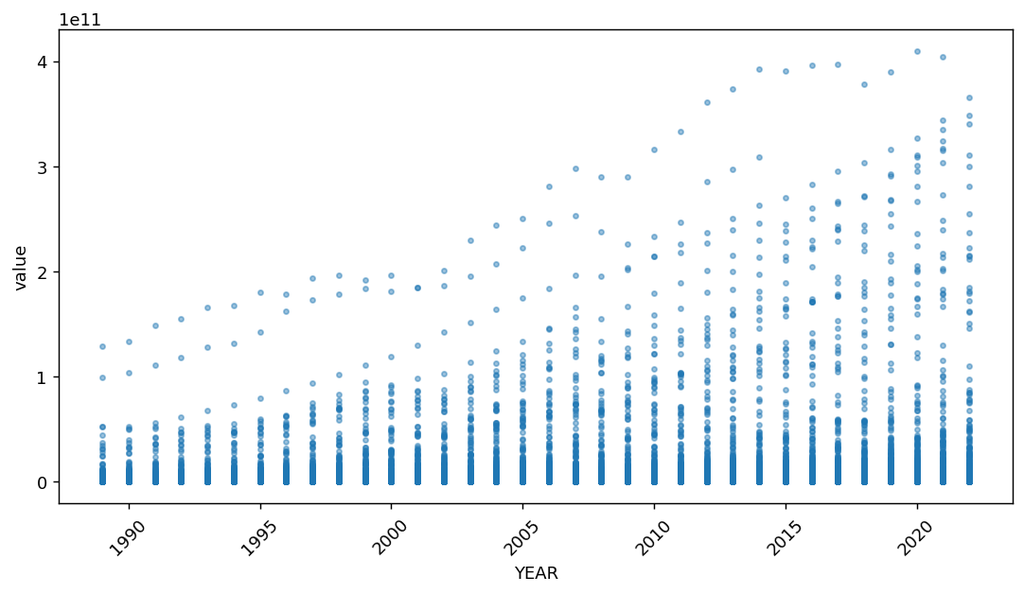

## 6. Comparing Total Asset Trends by Company Type

```
longdata |>
  filter(name == "Total") |>
  ggplot(aes(x = YEAR, y = value, color = COMPANY_TYPE_DESC)) +
  geom_point() +
  theme(
    axis.text.x = element_text(angle = 45, hjust = 1),
    legend.position = "bottom"
  )
```

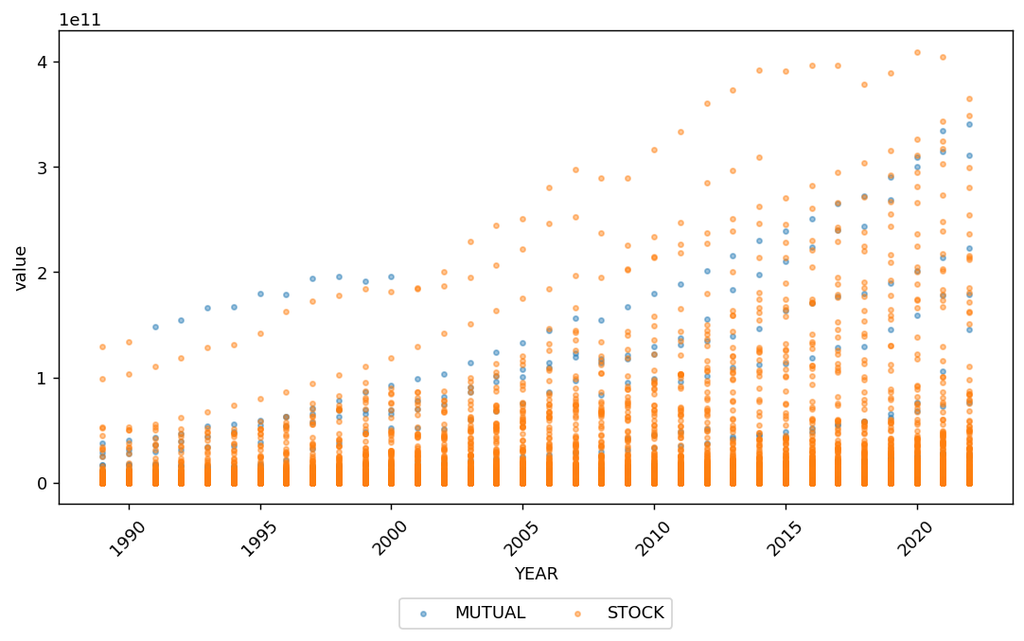

## 7. Analyzing Total Asset Distribution Over Time

```
longdata |>
  filter(name == "Total") |>
  ggplot(aes(x = YEAR, y = value)) +
  geom_boxplot() +
  theme(axis.text.x = element_text(angle = 45, hjust = 1))
```

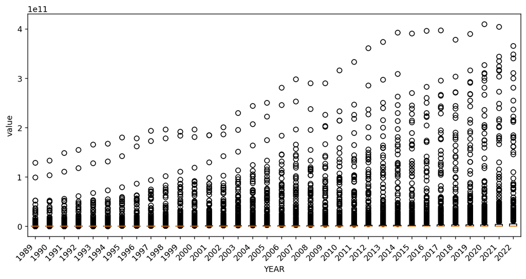

## 8. Focusing on the Total Asset Distribution

```
longdata |>
  filter(name == "Total") |>
  ggplot(aes(x = YEAR, y = value)) +
  geom_boxplot() +
  theme(axis.text.x = element_text(angle = 45, hjust = 1)) +
  ylim(c(0, 10^8))
```

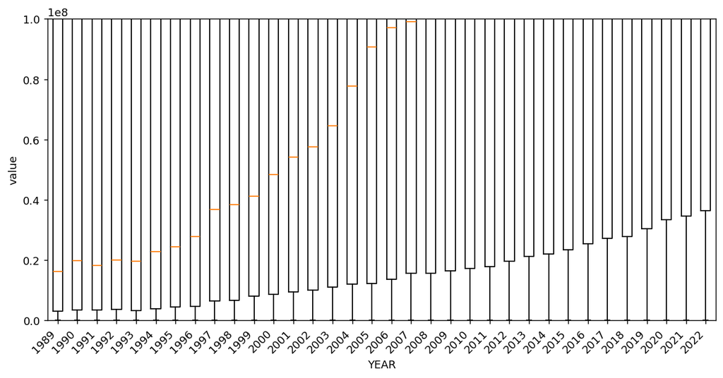

## 9. Analyzing Bond Ratio Distribution by Company Type

```
longdata |>
  filter(name == "bondRatio") |>
  ggplot(aes(x = YEAR, y = value, color = COMPANY_TYPE_DESC)) +
  geom_boxplot() +
  ylim(c(0, 1)) +
  theme(
    axis.text.x = element_text(angle = 45, hjust = 1),
    legend.position = "bottom"
  )
```

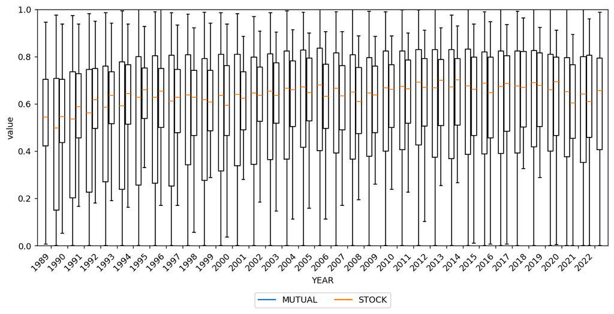

## 10. Comparing Bond and Stock Ratio Distributions by Company Type

```
longdata |>
  filter(name %in% c("bondRatio", "stockRatio")) |>
  ggplot(aes(x = YEAR, y = value, color = COMPANY_TYPE_DESC)) +
  geom_boxplot() +
  ylim(c(0, 1)) +
  facet_grid(name ~ COMPANY_TYPE_DESC) +
  theme(
    axis.text.x = element_text(angle = 45, hjust = 1),
    legend.position = "bottom"
  )
```

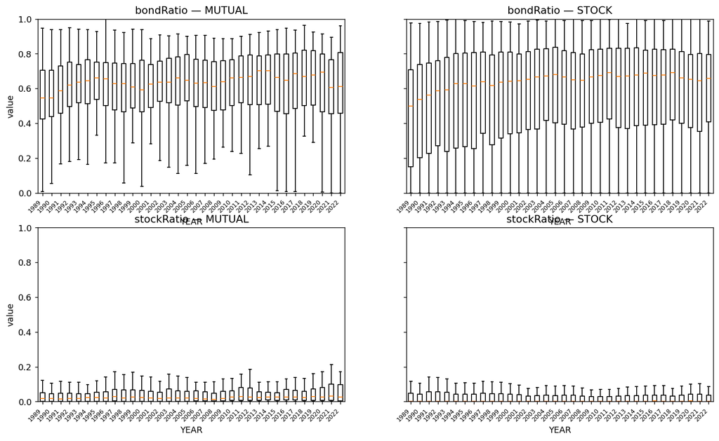

## 11. Visualizing Average Bond and Stock Ratios with Stacked Bars

```
ratio_summary <- longdata |>
  filter(name %in% c("bondRatio", "stockRatio")) |>
  pivot_wider(names_from = name, values_from = value) |>
  group_by(YEAR, COMPANY_TYPE_DESC) |>
  summarise(
    bondRatio = mean(bondRatio, na.rm = TRUE),
    stockRatio = mean(stockRatio, na.rm = TRUE),
    .groups = "drop"
  ) |>
  pivot_longer(
    cols = c(bondRatio, stockRatio),
    names_to = "name",
    values_to = "value"
  )

ratio_summary |>
  ggplot(aes(x = YEAR, y = value, fill = name)) +
  geom_col() +
  facet_wrap(~COMPANY_TYPE_DESC) +
  ylim(c(0, 1)) +
  labs(
    title = "Average Bond and Stock Ratios by Company Type",
    x = "Year",
    y = "Average Ratio",
    fill = "Ratio"
  ) +
  theme(
    axis.text.x = element_text(angle = 45, hjust = 1),
    legend.position = "bottom"
  )
```

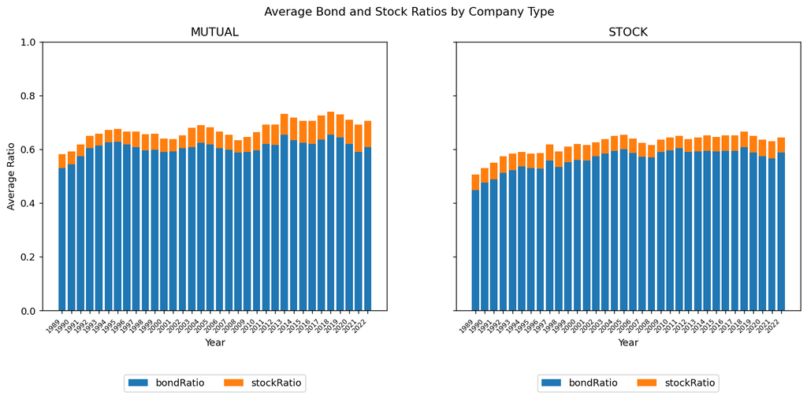

## 12. Brief Description of Findings

The visualizations show that total assets generally increased over time, although there is substantial variation across insurers and several very large outliers. The median total assets rose from about **$16.3 million in 1989** to about **$346.4 million in 2022**. Bonds make up a much larger share of assets than common stocks overall: the average bond ratio is about **55.4%**, compared with about **5.6%** for the stock ratio. Mutual companies have a somewhat higher average bond ratio than stock companies, while the average stock ratios are fairly similar. The focused box plots also make the typical distributions easier to see because the extreme asset values otherwise compress most observations near the bottom of the graph.